# Malware Classification using DeepImageSearch

The purpose of this notebook is to introduce the methodology of using Convolutional Neural Networks (CNN) for malware classification. This notebook selects a few CNNs loaded in DeepImageSearch to analyze malware and assess performance of each CNN.  
Python Version Executing this notebook: Python 3.11 (Anaconda 2024.02)  
Some code and data cells in this notebook may have been augmented from ChatGPT, Copilot, Gemini, other Generative AI models, and online resources.  
Notebook author: Solomon Sonya 0xSolomonSonya

# DeepImageSearch References

- Deep Image Search GitHub: https://github.com/TechyNilesh/DeepImageSearch/blob/main/Documents/Document.md
- DeepImageSearch: https://github.com/TechyNilesh/DeepImageSearch
- Tutorial: "How to Easily!! Find Similar Images in Python using Machine Learning with Deep Image Search" "https://www.youtube.com/watch?v=znM_Z_jYT8E

# Code Version

```python
CODE_VERSION = 1.43
```

# Imports

```python
import warnings
warnings.filterwarnings("ignore")

import pandas as pd
import numpy as np
import matplotlib.pyplot as plt
import seaborn as sns
import sys
import random
import pickle
import zipfile
import os
import pandas as pd
import time
import shutil
import inspect

# evaluation metrics
from sklearn import metrics
from sklearn.metrics import accuracy_score, precision_score, recall_score, r2_score
from sklearn.metrics import confusion_matrix, classification_report, precision_recall_curve
from sklearn.metrics import make_scorer,mean_squared_error, r2_score, mean_absolute_error
from sklearn.metrics import median_absolute_error, mean_absolute_percentage_error, rand_score
from sklearn.metrics import jaccard_score, dcg_score, consensus_score, d2_absolute_error_score
from sklearn.metrics import d2_pinball_score, d2_tweedie_score, davies_bouldin_score
from sklearn.metrics import log_loss
from sklearn.metrics import roc_auc_score, roc_curve
from sklearn.model_selection import cross_val_score
from sklearn.metrics import f1_score
from sklearn.metrics import auc, precision_recall_curve
from sklearn.metrics import cohen_kappa_score
from kneed import KneeLocator
from sklearn.metrics import silhouette_score
from sklearn.metrics import adjusted_rand_score, normalized_mutual_info_score
```

```python
#########################################################################################################
# Configure Deep Image Search
#########################################################################################################
configure_machine = False # change this to true if this is your first working with DeepImageSearch

if configure_machine:
    # you can try !pip install DeepImageSearch or !pip install deepimagesearch
    # I'm including both. If one fails to install, try the other one
    !pip install DeepImageSearch
    !pip install DeepImageSearch --upgrade
    print('\n', '#'*80, '\n # DeepImageSearch\n', '#'*80)
    !pip show DeepImageSearch
    print('\n')

    # try this configuration as well - some python installations prefer the above, others work with the below install
    !pip install deepimagesearch
    !pip install deepimagesearch  --upgrade

    !pip install timm
    !pip install py7zr
    #!pip uninstall -y torch torchvision
    #!pip install torch torchvision

    print('\n', '*'*90, '\n', '* If this is your first time configuring your machine for DeepImageSearch, \n * please RESTART JUPYTER NOTEBOOK KERNEL to ensure kernel updates correctly.\n', '*'*90, '\n')

print('configuration complete')
```

```
configuration complete
```

```python
import timm
import py7zr
from pprint import pprint
import torch
import torchvision
```

```python
from DeepImageSearch import Load_Data, Search_Setup
# depending on your pythong environment, try this line if the above import DeepImageSearch fails
#from deepimagesearch import Load_Data, Search_Setup
print('\nimport complete!')
```

```
import complete!
```

# Configure environment

```python
os.makedirs('output', exist_ok=True)
```

# Specify to load previously trained models

```python
LOAD_PRETRAINED_MODELS = False
path_to_pretrained_models = './trained_models'
```

# Set Options

```python
pd.set_option('display.max_rows', None)
pd.set_option('display.max_columns', None)
```

# Set input file path

```python
#zip_file = './grayscale_pw_infected.7z'
#zip_password = 'infected'
#extract_to = './grayscale'
extract_to = '/home/remnux/Desktop/workshop/cnn/input/grayscale/'
```

# Extract Archive

```python
# Extract .7z archive
#with py7zr.SevenZipFile(zip_file, mode='r', password=zip_password) as archive:
#    archive.extractall(path=extract_to)

#print(f"Extraction complete! Files extracted to {extract_to}")
```

# Rescale images to 224 x 224

```python
rescale = True

if rescale:
    from PIL import Image
    import os

    # Path to the root folder containing images
    root_folder = extract_to

    # Set dimensions
    new_width = 224
    new_height = 224

    # Function to resize and convert images to grayscale

    def process_image(image_path, width, height):
        # Open the image
        img = Image.open(image_path)
        # Get the original dimensions
        original_width, original_height = img.size
        # Resize the image to specified dimensions
        img = img.resize((width, height), resample=Image.Resampling.LANCZOS)
        # Convert the image to grayscale
        img = img.convert("L")  # "L" mode for grayscale
        # Save the resized and converted image, overwriting the original image
        img.save(image_path)
        # Get the new dimensions
        new_width, new_height = img.size
        # Print the dimensions
        print(f"Resized {os.path.basename(image_path)} from {original_width}x{original_height} to {new_width}x{new_height} pixels.")

    # Recursively iterate over files in the root folder and its subfolders
    for root, dirs, files in os.walk(root_folder):
        for file in files:
            # Check if the file is an image (you can add more image extensions if needed)
            if file.lower().endswith(('.png', '.jpg', '.jpeg', '.gif', '.bmp')):
                # Construct the full path to the image file
                image_path = os.path.join(root, file)
                # Process the image (resize and convert to grayscale)
                process_image(image_path, new_width, new_height)

    print(f'\nComplete! All images resized to {new_width}x{new_height} pixels and converted to grayscale.')
```

[output not shown]

[output cut: 101 more lines]

[output not shown]

# Import images

```python
original_image_list = Load_Data().from_folder([extract_to])

# sort list
image_list = sorted(original_image_list, key=lambda x: x.lower())

# create dictionary of path to image index
dict_path_to_image_index = dict()

# create reverse path to family name lookup
dict_family_from_path = dict()

# create dictionary of unique families
dict_unique_families = dict()

for i in range(len(image_list)):
    print(f'[{i}]\t{image_list[i]}')
    dict_path_to_image_index[image_list[i]] = i

    # extract unique family name - list of paths for each family
    family_name = image_list[i][len(extract_to):]
    if family_name.startswith(os.sep):
        family_name = family_name[1:]
    family_name = family_name[:family_name.index(os.sep)].strip()

    if not family_name in dict_unique_families:
        dict_unique_families[family_name] = list()
    # append entry
    dict_unique_families[family_name].append(image_list[i])

    # store in reverse loopup dict as well
    dict_family_from_path[image_list[i]] = family_name
```

```
[0]	/home/remnux/Desktop/workshop/cnn/input/grayscale/7ev3n/grayscale_square_66e1592e69420d6046dfc44ac8d9c45e9f563fb533cdc13d9565ae6a5438ef51.png
[1]	/home/remnux/Desktop/workshop/cnn/input/grayscale/7ev3n/grayscale_square_7cea675f189ce2987119cd5963038b24730c8d04dac36ee14c9b9628bdd93af8.png
[2]	/home/remnux/Desktop/workshop/cnn/input/grayscale/7ev3n/grayscale_square_bbfda711882063cc7b41b55dbdabf3a92a4e9b1d6c3c358bf33f1e64d942e53b.png
[3]	/home/remnux/Desktop/workshop/cnn/input/grayscale/7ev3n/grayscale_square_bd67c57b7b25c4a288f7253d5d9f4b371c2ec252ac495554108fa2609fa0242d.png
[4]	/home/remnux/Desktop/workshop/cnn/input/grayscale/7ev3n/grayscale_square_ca97d1b9ec53b7d4d860d1440802b4f8d0491f839463325e8104993212b25cca.png
[5]	/home/remnux/Desktop/workshop/cnn/input/grayscale/7ev3n/grayscale_square_f0eed1b99d5ea1c62d76dee2cb00b6037782a190eb9c17daaad9de0d44a3ec85.png
[6]	/home/remnux/Desktop/workshop/cnn/input/grayscale/7ev3n/grayscale_square_fdebe4aca409ff392986086f8eaad120499cb60738c927ec64def14f330d3b0b.png
[7]	/home/remnux/Desktop/workshop/cnn/input/grayscale/9002Rat/grayscale_square_09e58c7bc6edef6dff730c06962d1815ddfd2324412c7cade4af5f01df70dfd4.png
[8]	/home/remnux/Desktop/workshop/cnn/input/grayscale/9002Rat/grayscale_square_1442877711143210fc930295ceb55eb711c692bd0cb7cf6ab709be2af4ef0f74.png
[9]	/home/remnux/Desktop/workshop/cnn/input/grayscale/9002Rat/grayscale_square_3124fcb79da0bdf9d0d1995e37b06f7929d83c1c4b60e38c104743be71170efe.png
[10]	/home/remnux/Desktop/workshop/cnn/input/grayscale/9002Rat/grayscale_square_56d5fd3de23fd1aefc30dd3fa9b38767ca12099a62d4745859edfe0bd9e8601b.png
[11]	/home/remnux/Desktop/workshop/cnn/input/grayscale/9002Rat/grayscale_square_b5817f0a289c55f52647a2b6925578370d4bb91dbc89056673dc07197c7e4621.png
[12]	/home/remnux/Desktop/workshop/cnn/input/grayscale/9002Rat/grayscale_square_c95d38d92f81e8d0fe6a664f6aa0cb1001916715e51b25efd85f192afbc87b2e.png
[13]	/home/remnux/Desktop/workshop/cnn/input/grayscale/AgentTesla/grayscale_square_0e11704fcc3c36832ba98b80ea44a3013660d1ed3fb48158b982fed9f9050391.png
[14]	/home/remnux/Desktop/workshop/cnn/input/grayscale/AgentTesla/grayscale_square_1559eb5515eb732de889dcdff24662c9.png
[15]	/home/remnux/Desktop/workshop/cnn/input/grayscale/AgentTesla/grayscale_square_19116e822e8178fc103e51fe18c825a4.png
[16]	/home/remnux/Desktop/workshop/cnn/input/grayscale/AgentTesla/grayscale_square_413ca1f198008a2980f7891c059bc188.png
[17]	/home/remnux/Desktop/workshop/cnn/input/grayscale/AgentTesla/grayscale_square_5b14a7366cf5dbea3386c6afbd25f012.png
[18]	/home/remnux/Desktop/workshop/cnn/input/grayscale/AgentTesla/grayscale_square_81afa08f1a1acfa3fd9f52ecadda2f55.png
[19]	/home/remnux/Desktop/workshop/cnn/input/grayscale/AgentTesla/grayscale_square_bc9f0c07dfe0016049662acbafe3c96f.png
[20]	/home/remnux/Desktop/workshop/cnn/input/grayscale/AgentTesla/grayscale_square_f8efaa5826c602395a6317abb2905a25.png
[21]	/home/remnux/Desktop/workshop/cnn/input/grayscale/Bankshot/grayscale_square_56a6a4a16cbe7692ab3e36fbb181c2c9614ea06065ba2316395c6196cf3a5d1f.png
[22]	/home/remnux/Desktop/workshop/cnn/input/grayscale/Bankshot/grayscale_square_582789fabf681d2a1148373aaecf9c2e8974770258c440d398dcafe3d4ddd8a5.png
[23]	/home/remnux/Desktop/workshop/cnn/input/grayscale/Bankshot/grayscale_square_9e74ffcd50b75d36850637e0c1bca2d9761e9c1ada63712e862db346bca68b35.png
[24]	/home/remnux/Desktop/workshop/cnn/input/grayscale/Bizarro/grayscale_square_07e1ed9c60ef84688cb35923166762cff3325e058dff59a65549efcd22297436.png
[25]	/home/remnux/Desktop/workshop/cnn/input/grayscale/Bizarro/grayscale_square_202ee8b14ac2dff31910820fed613252d813aea22b015179975988308c0f1c85.png
[26]	/home/remnux/Desktop/workshop/cnn/input/grayscale/Bizarro/grayscale_square_261b9e4b576b1d2a1c4ce44a4b48cd776981e392615c8ee5556c066b82aeca21.png
[27]	/home/remnux/Desktop/workshop/cnn/input/grayscale/Bizarro/grayscale_square_684e6bdced0521344b38a3dbd0ee159a0691ca47a766a3f0ea8ca5578ed0816d.png
[28]	/home/remnux/Desktop/workshop/cnn/input/grayscale/Bizarro/grayscale_square_8c30d08ef7a407fc32e721dd8d8f49260faf0451b41d7be5d61dd89361fb5d03.png
[29]	/home/remnux/Desktop/workshop/cnn/input/grayscale/Bizarro/grayscale_square_9e533c9f14375ca958fadc504b80dd89569a33b70275362bb1b6b6f9f27d03b8.png
[30]	/home/remnux/Desktop/workshop/cnn/input/grayscale/Bizarro/grayscale_square_e13fe434eb19987ee1239caae2eca96df2cd2d78dec0f8d414e04b856bcf2b2e.png
[31]	/home/remnux/Desktop/workshop/cnn/input/grayscale/Bizarro/grayscale_square_f57fc4857a76fe66cb8eb0bbc9e88d9e70f9de2135d4802c7c18f89bd92060a9.png
[32]	/home/remnux/Desktop/workshop/cnn/input/grayscale/BruteRatel/grayscale_square_31ACF37D180AB9AFBCF6A4EC5D29C3E19C947641A2D9CE3CE56D71C1F576C069.png
[33]	/home/remnux/Desktop/workshop/cnn/input/grayscale/BruteRatel/grayscale_square_3AD53495851BAFC48CAF6D2227A434CA2E0BEF9AB3BD40ABFE4EA8F318D37BBE.png
[34]	/home/remnux/Desktop/workshop/cnn/input/grayscale/BruteRatel/grayscale_square_3ED21A4BFCF9838E06AD3058D13D5C28026C17DC996953A22A00F0609B0DF3B9.png
[35]	/home/remnux/Desktop/workshop/cnn/input/grayscale/BruteRatel/grayscale_square_973F573CAB683636D9A70B8891263F59E2F02201FFB4DD2E9D7ECBB1521DA03E.png
[36]	/home/remnux/Desktop/workshop/cnn/input/grayscale/BruteRatel/grayscale_square_DD8652E2DCFE3F1A72631B3A9585736FBE77FFABEE4098F6B3C48E1469BF27AA.png
[37]	/home/remnux/Desktop/workshop/cnn/input/grayscale/CobaltStrike/grayscale_square_132bdcb986e3e3b9599b5b293b3318e7c630495e87a9d1fa02287ae80f9e652f.png
[38]	/home/remnux/Desktop/workshop/cnn/input/grayscale/CobaltStrike/grayscale_square_2160af903da06c25c2f6426931d20eb7e7a8ea6f9951e144188027252ff64281.png
[39]	/home/remnux/Desktop/workshop/cnn/input/grayscale/CobaltStrike/grayscale_square_7c2ea97f8fff301a03f36fb6b87d08dc81e948440c87c2805b9e4622eb4e1991.png
```

[output cut: 99 more lines]

```
[139]	/home/remnux/Desktop/workshop/cnn/input/grayscale/Virlock/grayscale_square_CBFB54371620E4BD2BAB45B5C7AD91D3D896BC6324F621B1FB7457F43E3AEB82.png
[140]	/home/remnux/Desktop/workshop/cnn/input/grayscale/Virlock/grayscale_square_E95D6D0DDB67A70A2C52D9729E2B33E76500FF99551FB91CF610C65F20C7CD2C.png
[141]	/home/remnux/Desktop/workshop/cnn/input/grayscale/WinMM/grayscale_square_5880001cbee1a67fd3e898d38dbe14e97d0f4d19e290ce3d63de85f283d43bae.png
[142]	/home/remnux/Desktop/workshop/cnn/input/grayscale/WinMM/grayscale_square_7e3489d42f56d6ef975ed7d6cd7b926737e7fcb71b0f0ca8ded8678e7c85c0db.png
[143]	/home/remnux/Desktop/workshop/cnn/input/grayscale/WinMM/grayscale_square_8713bafa5457ef9b89bd52330b8e0be2f0903ede1e55ef457494b7fe82c9b182.png
[144]	/home/remnux/Desktop/workshop/cnn/input/grayscale/WinMM/grayscale_square_af3fbe4df7f2bd0240c5fda23b7f64ec57557e1da53d21a579a9faff6023e89d.png
[145]	/home/remnux/Desktop/workshop/cnn/input/grayscale/WinMM/grayscale_square_e551e2105969587b635e0186a5b3cbf25251912cff9e20945091989966e4d074.png
[146]	/home/remnux/Desktop/workshop/cnn/input/grayscale/Zeus/grayscale_square_3715907255600507abee3e855c0c47269a9fb0eca9cfc9505cc3ff51dc310e32.png
[147]	/home/remnux/Desktop/workshop/cnn/input/grayscale/Zeus/grayscale_square_385319c04e4ae7036da4adfc8e5182809408618f2960fa54adf01325f24cd01a.png
[148]	/home/remnux/Desktop/workshop/cnn/input/grayscale/Zeus/grayscale_square_9d490b59563bddf957ff07fe8c4a0806b6b67691e2ffc9ca4a828f6dd67bc23b.png
[149]	/home/remnux/Desktop/workshop/cnn/input/grayscale/Zeus/grayscale_square_adddb74a585d301eceb4deeeafdb69ffc32637a2354f3fd301e758bae7f30971.png
[150]	/home/remnux/Desktop/workshop/cnn/input/grayscale/Zeus/grayscale_square_c4ae927e211fe408801c98892315d2f159a9ab104a2d25ede0e6b3c5679b083f.png
[151]	/home/remnux/Desktop/workshop/cnn/input/grayscale/Zeus/grayscale_square_ce5d359c2f5cb64f9678527aea6d9830d0a25b46c5f38777c5355ae251900ce5.png
[152]	/home/remnux/Desktop/workshop/cnn/input/grayscale/Zeus/grayscale_square_f0ea1d50f03d5eb0f86dc8a7ed087e821b54f47f6bc112a6b62442974e336914.png
[153]	/home/remnux/Desktop/workshop/cnn/input/grayscale/Zeus/grayscale_square_f804e6d969529af3f52ed4b563164fc570136098fa955cdeb210f8bfa4c868fd.png
```

# View Images labeled to each class

```python
print('malware paths per family: \n================================================')
pprint(dict_unique_families)
```

```
malware paths per family:
================================================
{'7ev3n': ['/home/remnux/Desktop/workshop/cnn/input/grayscale/7ev3n/grayscale_square_66e1592e69420d6046dfc44ac8d9c45e9f563fb533cdc13d9565ae6a5438ef51.png',
           '/home/remnux/Desktop/workshop/cnn/input/grayscale/7ev3n/grayscale_square_7cea675f189ce2987119cd5963038b24730c8d04dac36ee14c9b9628bdd93af8.png',
           '/home/remnux/Desktop/workshop/cnn/input/grayscale/7ev3n/grayscale_square_bbfda711882063cc7b41b55dbdabf3a92a4e9b1d6c3c358bf33f1e64d942e53b.png',
           '/home/remnux/Desktop/workshop/cnn/input/grayscale/7ev3n/grayscale_square_bd67c57b7b25c4a288f7253d5d9f4b371c2ec252ac495554108fa2609fa0242d.png',
           '/home/remnux/Desktop/workshop/cnn/input/grayscale/7ev3n/grayscale_square_ca97d1b9ec53b7d4d860d1440802b4f8d0491f839463325e8104993212b25cca.png',
           '/home/remnux/Desktop/workshop/cnn/input/grayscale/7ev3n/grayscale_square_f0eed1b99d5ea1c62d76dee2cb00b6037782a190eb9c17daaad9de0d44a3ec85.png',
           '/home/remnux/Desktop/workshop/cnn/input/grayscale/7ev3n/grayscale_square_fdebe4aca409ff392986086f8eaad120499cb60738c927ec64def14f330d3b0b.png'],
 '9002Rat': ['/home/remnux/Desktop/workshop/cnn/input/grayscale/9002Rat/grayscale_square_09e58c7bc6edef6dff730c06962d1815ddfd2324412c7cade4af5f01df70dfd4.png',
             '/home/remnux/Desktop/workshop/cnn/input/grayscale/9002Rat/grayscale_square_1442877711143210fc930295ceb55eb711c692bd0cb7cf6ab709be2af4ef0f74.png',
             '/home/remnux/Desktop/workshop/cnn/input/grayscale/9002Rat/grayscale_square_3124fcb79da0bdf9d0d1995e37b06f7929d83c1c4b60e38c104743be71170efe.png',
             '/home/remnux/Desktop/workshop/cnn/input/grayscale/9002Rat/grayscale_square_56d5fd3de23fd1aefc30dd3fa9b38767ca12099a62d4745859edfe0bd9e8601b.png',
             '/home/remnux/Desktop/workshop/cnn/input/grayscale/9002Rat/grayscale_square_b5817f0a289c55f52647a2b6925578370d4bb91dbc89056673dc07197c7e4621.png',
             '/home/remnux/Desktop/workshop/cnn/input/grayscale/9002Rat/grayscale_square_c95d38d92f81e8d0fe6a664f6aa0cb1001916715e51b25efd85f192afbc87b2e.png'],
 'AgentTesla': ['/home/remnux/Desktop/workshop/cnn/input/grayscale/AgentTesla/grayscale_square_0e11704fcc3c36832ba98b80ea44a3013660d1ed3fb48158b982fed9f9050391.png',
                '/home/remnux/Desktop/workshop/cnn/input/grayscale/AgentTesla/grayscale_square_1559eb5515eb732de889dcdff24662c9.png',
                '/home/remnux/Desktop/workshop/cnn/input/grayscale/AgentTesla/grayscale_square_19116e822e8178fc103e51fe18c825a4.png',
                '/home/remnux/Desktop/workshop/cnn/input/grayscale/AgentTesla/grayscale_square_413ca1f198008a2980f7891c059bc188.png',
                '/home/remnux/Desktop/workshop/cnn/input/grayscale/AgentTesla/grayscale_square_5b14a7366cf5dbea3386c6afbd25f012.png',
                '/home/remnux/Desktop/workshop/cnn/input/grayscale/AgentTesla/grayscale_square_81afa08f1a1acfa3fd9f52ecadda2f55.png',
                '/home/remnux/Desktop/workshop/cnn/input/grayscale/AgentTesla/grayscale_square_bc9f0c07dfe0016049662acbafe3c96f.png',
                '/home/remnux/Desktop/workshop/cnn/input/grayscale/AgentTesla/grayscale_square_f8efaa5826c602395a6317abb2905a25.png'],
 'Bankshot': ['/home/remnux/Desktop/workshop/cnn/input/grayscale/Bankshot/grayscale_square_56a6a4a16cbe7692ab3e36fbb181c2c9614ea06065ba2316395c6196cf3a5d1f.png',
              '/home/remnux/Desktop/workshop/cnn/input/grayscale/Bankshot/grayscale_square_582789fabf681d2a1148373aaecf9c2e8974770258c440d398dcafe3d4ddd8a5.png',
              '/home/remnux/Desktop/workshop/cnn/input/grayscale/Bankshot/grayscale_square_9e74ffcd50b75d36850637e0c1bca2d9761e9c1ada63712e862db346bca68b35.png'],
 'Bizarro': ['/home/remnux/Desktop/workshop/cnn/input/grayscale/Bizarro/grayscale_square_07e1ed9c60ef84688cb35923166762cff3325e058dff59a65549efcd22297436.png',
             '/home/remnux/Desktop/workshop/cnn/input/grayscale/Bizarro/grayscale_square_202ee8b14ac2dff31910820fed613252d813aea22b015179975988308c0f1c85.png',
             '/home/remnux/Desktop/workshop/cnn/input/grayscale/Bizarro/grayscale_square_261b9e4b576b1d2a1c4ce44a4b48cd776981e392615c8ee5556c066b82aeca21.png',
             '/home/remnux/Desktop/workshop/cnn/input/grayscale/Bizarro/grayscale_square_684e6bdced0521344b38a3dbd0ee159a0691ca47a766a3f0ea8ca5578ed0816d.png',
             '/home/remnux/Desktop/workshop/cnn/input/grayscale/Bizarro/grayscale_square_8c30d08ef7a407fc32e721dd8d8f49260faf0451b41d7be5d61dd89361fb5d03.png',
             '/home/remnux/Desktop/workshop/cnn/input/grayscale/Bizarro/grayscale_square_9e533c9f14375ca958fadc504b80dd89569a33b70275362bb1b6b6f9f27d03b8.png',
             '/home/remnux/Desktop/workshop/cnn/input/grayscale/Bizarro/grayscale_square_e13fe434eb19987ee1239caae2eca96df2cd2d78dec0f8d414e04b856bcf2b2e.png',
             '/home/remnux/Desktop/workshop/cnn/input/grayscale/Bizarro/grayscale_square_f57fc4857a76fe66cb8eb0bbc9e88d9e70f9de2135d4802c7c18f89bd92060a9.png'],
 'BruteRatel': ['/home/remnux/Desktop/workshop/cnn/input/grayscale/BruteRatel/grayscale_square_31ACF37D180AB9AFBCF6A4EC5D29C3E19C947641A2D9CE3CE56D71C1F576C069.png',
                '/home/remnux/Desktop/workshop/cnn/input/grayscale/BruteRatel/grayscale_square_3AD53495851BAFC48CAF6D2227A434CA2E0BEF9AB3BD40ABFE4EA8F318D37BBE.png',
                '/home/remnux/Desktop/workshop/cnn/input/grayscale/BruteRatel/grayscale_square_3ED21A4BFCF9838E06AD3058D13D5C28026C17DC996953A22A00F0609B0DF3B9.png',
                '/home/remnux/Desktop/workshop/cnn/input/grayscale/BruteRatel/grayscale_square_973F573CAB683636D9A70B8891263F59E2F02201FFB4DD2E9D7ECBB1521DA03E.png',
                '/home/remnux/Desktop/workshop/cnn/input/grayscale/BruteRatel/grayscale_square_DD8652E2DCFE3F1A72631B3A9585736FBE77FFABEE4098F6B3C48E1469BF27AA.png'],
 'CobaltStrike': ['/home/remnux/Desktop/workshop/cnn/input/grayscale/CobaltStrike/grayscale_square_132bdcb986e3e3b9599b5b293b3318e7c630495e87a9d1fa02287ae80f9e652f.png',
```

[output cut: 101 more lines]

```
          '/home/remnux/Desktop/workshop/cnn/input/grayscale/Zeus/grayscale_square_385319c04e4ae7036da4adfc8e5182809408618f2960fa54adf01325f24cd01a.png',
          '/home/remnux/Desktop/workshop/cnn/input/grayscale/Zeus/grayscale_square_9d490b59563bddf957ff07fe8c4a0806b6b67691e2ffc9ca4a828f6dd67bc23b.png',
          '/home/remnux/Desktop/workshop/cnn/input/grayscale/Zeus/grayscale_square_adddb74a585d301eceb4deeeafdb69ffc32637a2354f3fd301e758bae7f30971.png',
          '/home/remnux/Desktop/workshop/cnn/input/grayscale/Zeus/grayscale_square_c4ae927e211fe408801c98892315d2f159a9ab104a2d25ede0e6b3c5679b083f.png',
          '/home/remnux/Desktop/workshop/cnn/input/grayscale/Zeus/grayscale_square_ce5d359c2f5cb64f9678527aea6d9830d0a25b46c5f38777c5355ae251900ce5.png',
          '/home/remnux/Desktop/workshop/cnn/input/grayscale/Zeus/grayscale_square_f0ea1d50f03d5eb0f86dc8a7ed087e821b54f47f6bc112a6b62442974e336914.png',
          '/home/remnux/Desktop/workshop/cnn/input/grayscale/Zeus/grayscale_square_f804e6d969529af3f52ed4b563164fc570136098fa955cdeb210f8bfa4c868fd.png'],
 'gameover': ['/home/remnux/Desktop/workshop/cnn/input/grayscale/gameover/grayscale_square_13c5b33339522f8f96d091708e7a8a64b0939daa6225732352fbe44cb2950e67.png',
              '/home/remnux/Desktop/workshop/cnn/input/grayscale/gameover/grayscale_square_532efdeecae3b32d83f032a1a69c28b5f4d2f2d8ebaeeaf54eda57a67fc0fd2c.png',
              '/home/remnux/Desktop/workshop/cnn/input/grayscale/gameover/grayscale_square_6af396928548eca6d87552918a94ed47e600dd11a7693bbb18e0949096ac2dee.png',
              '/home/remnux/Desktop/workshop/cnn/input/grayscale/gameover/grayscale_square_76ea56f0200d7138016794926eebb2a477cf2b1bd01eafbf4c2404eb7c876de2.png',
              '/home/remnux/Desktop/workshop/cnn/input/grayscale/gameover/grayscale_square_86bcfce2dd342e9a1c04cfc65731d40ed1c397a4ec47bd9f5b41771297d81100.png',
              '/home/remnux/Desktop/workshop/cnn/input/grayscale/gameover/grayscale_square_da286c05353e0dc14d8a18043f9ccb4df6de18f52f9942f355382ec0ef3212a9.png',
              '/home/remnux/Desktop/workshop/cnn/input/grayscale/gameover/grayscale_square_dbcdef61ed483295ae58d02bc83d11d2585443f2014d329fa8b0318891009d65.png',
              '/home/remnux/Desktop/workshop/cnn/input/grayscale/gameover/grayscale_square_efe94c134ed00c0459ff93c291faddabcdf5cf1f7db0594dda95df6c43a98808.png']}
```

```python
print("Total Image Count:", len(image_list))
print("Samples:")
pprint(image_list[:5])
```

```
Total Image Count: 154
Samples:
['/home/remnux/Desktop/workshop/cnn/input/grayscale/7ev3n/grayscale_square_66e1592e69420d6046dfc44ac8d9c45e9f563fb533cdc13d9565ae6a5438ef51.png',
 '/home/remnux/Desktop/workshop/cnn/input/grayscale/7ev3n/grayscale_square_7cea675f189ce2987119cd5963038b24730c8d04dac36ee14c9b9628bdd93af8.png',
 '/home/remnux/Desktop/workshop/cnn/input/grayscale/7ev3n/grayscale_square_bbfda711882063cc7b41b55dbdabf3a92a4e9b1d6c3c358bf33f1e64d942e53b.png',
 '/home/remnux/Desktop/workshop/cnn/input/grayscale/7ev3n/grayscale_square_bd67c57b7b25c4a288f7253d5d9f4b371c2ec252ac495554108fa2609fa0242d.png',
 '/home/remnux/Desktop/workshop/cnn/input/grayscale/7ev3n/grayscale_square_ca97d1b9ec53b7d4d860d1440802b4f8d0491f839463325e8104993212b25cca.png']
```

# List possible CNN Image Search Models

```python
# Get a list of pretrained models
pretrained_models = timm.list_models(pretrained=True)  # You can set to False to initialize training from scratch

# Print the count of pretrained models
print(f'Count of pretrained models: {len(pretrained_models)}')

# Print models in 3 columns
num_columns = 3

# Calculate the number of rows needed
num_rows = (len(pretrained_models) + num_columns - 1) // num_columns

# Print the models in a grid with indices
print("\nPretrained models:")
for i in range(num_rows):
    row_models = pretrained_models[i * num_columns:(i + 1) * num_columns]

    # Enumerate models and format with index
    formatted_models = [f"[{i * num_columns + j + 1}] {model: <45}" for j, model in enumerate(row_models)]

    # Print each row
    print("  ".join(formatted_models))
```

[output not shown]

[output cut: 474 more lines]

# Write Names of Pretrained Models to File

```python
# you can research these models to learn more about specific ones
file_path = "./output/deep_image_search_pretrained_models.txt"


pretrained_models = timm.list_models(pretrained=True)
with open(file_path, "w") as file:
    # Write each model name to the file
    for model_name in pretrained_models:
        file.write(model_name + "\n")


print(f"Pretrained models list written to {file_path}")
```

```
Pretrained models list written to ./output/deep_image_search_pretrained_models.txt
```

# Helper function

```python
##########################################################
########################
#################
def print_exception(error, mtd_name, print_stack_trace):
   print("\n*\n\n* * * Exception Caught in mtd \"" + mtd_name + "\" Type [", type(error).__name__, "] at line number [",error.__traceback__.tb_lineno, "] error message \"[", error, "]\n*\n*\n*\n")


   if print_stack_trace:
       traceback.print_exc()
```

# Specify models

```python
# you can use the full name e.g. 'resnet50.a1_in1k' to specify the CNN you'd like to use
lst_models = ['resnet50',
              #'efficientnet_b4.ra2_in1k',
              'darknet53',
              #'resnext101_64x4d',
              'vgg19',
              'inception_v4',
              #'densenet201.tv_in1k',
              'xception71',
              #'tresnet_xl',
              #'rexnetr_300.sw_in12k_ft_in1k',
]
```

# Create Dataframe for Evaluation Score Values

```python
# define cols
cols = ['model_name',
           'precision',
           'recall',
           'f1_score',
           'accuracy',
           'TP',
           'FP',
           'execution_time_mins'
]

# create df
df_evaluation_score = pd.DataFrame(columns=cols)
```

# Create for training and test hold-out

```python
# set test size
tst_size = 0.20

dict_training = dict()
dict_test = dict()

# overall list of paths
lst_training = list()
lst_test = list()

# set the seed for reproducibility
random.seed(42)

# dict_path_to_image_index is populated previously

# iterate through the image list for each family label
for family_name in dict_unique_families.keys():
    # get the list of entries
    lst_paths = dict_unique_families[family_name]

    # get count of entries
    entry_count = len(lst_paths)

    # determine test hold-out count
    count_test_hold_out = int(np.ceil(float(entry_count) * tst_size))

    # shuffle the list
    shuffled_list = list(lst_paths)
    random.shuffle(shuffled_list)

    # finally, assign the first (SHUFFLED) entries to test, and the rest to training
    dict_test[family_name] = list(lst_paths[:count_test_hold_out])
    dict_training[family_name] = list(lst_paths[count_test_hold_out:])

    # append overall lists
    lst_test = lst_test + lst_paths[:count_test_hold_out]
    lst_training = lst_training + lst_paths[count_test_hold_out:]


print(f'size of test set: {len(lst_test)}')
print(f'size of training set: {len(lst_training)}')
print(f'total size of training + test dataset: {len(lst_test) + len(lst_training)}')
```

```
size of test set: 39
size of training set: 115
total size of training + test dataset: 154
```

# Bifurcate label from full path

```python
lst_TEST_LABELS_ONLY = list()
lst_TRAINING_LABELS_ONLY = list()

def get_label_from_path(lst_path, header_path):
    lst = list()

    for pth in lst_test:

        # remove header: - start at index value right after extract_to path
        LABEL = pth[len(extract_to):]

        # remove tail: start from beginning until next file separator
        LABEL = LABEL[:LABEL.index(os.sep)]

        lst.append(LABEL)

    # out of loop
    return lst

# we will use these in our evaluation calculations
lst_TEST_LABELS_ONLY = get_label_from_path(lst_test, extract_to)
lst_TRAINING_LABELS_ONLY = get_label_from_path(lst_training, extract_to)
```

# Train & Evaluate the Models!

```python
%%time

REMOVE_PREV_TRAINED_MODEL = True

dict_trained_models = dict()

# key == model name, value for each model will be another tree counting the number of labels for each class
dict_confusion_matrix = dict()

# specifically holds count of TP successfully identified by the model (not just the count from confusion matrix)
dict_TP_matrix = dict()

# iterate through each model
for mdl_name in lst_models:

    ##########################################################################################################################################################
    # Train
    ##########################################################################################################################################################

    # Start time
    start_time = time.time()

    dict_confusion_matrix[mdl_name] = dict()
    dict_TP_matrix[mdl_name] = dict()

    # notify
    notify = False

    # remove prev trained directory
    if REMOVE_PREV_TRAINED_MODEL:
        try:
            # skip if directory does not exist
            if os.path.isdir('./metadata-files/' + str(mdl_name)):
                # remove directory
                shutil.rmtree('./metadata-files/' + str(mdl_name))
        except Exception as error:
            #print_exception(error, inspect.currentframe().f_code.co_name + " on model --> " + str(mdl_name), False)
            #print("\n\n* * * NOTE: I could not remove prev metadata directory * * *\n\n")
            pass



    # training model
    print('\n')
    print('#'*100)
    print(f"# commencing training on model --> {mdl_name}")
    print('#'*100)

    # instantiate model
    st = Search_Setup(image_list=lst_training, model_name=mdl_name, pretrained=False, image_count=None)

    # Index the images - Train the model
    st.run_index()

    # Get metadata
    metadata = st.get_image_metadata_file()
    if notify:
        print('\n features\n=====================================================================================================')
        print(metadata)

    # link the trained model
    dict_trained_models[mdl_name] = st

    ##########################################################################################################################################################
    # save trained model
    ##########################################################################################################################################################

    # create output top folder
    #saved_trained_models_path_to_top_folder = 'trained_models'
    #os.makedirs(saved_trained_models_path_to_top_folder, exist_ok=True)
    os.makedirs(path_to_pretrained_models, exist_ok=True)

    # save trained model
    model_path = os.path.join(path_to_pretrained_models, str(mdl_name) + '.pkl')
    with open(model_path, 'wb') as fos_trained_model:
        pickle.dump(st, fos_trained_model)

    # notify
    print(f'{mdl_name} training complete. Trained model saved to --> {model_path}\n')

                #                         PREDICTED CLASS
                #                         --------------
                #                     POSITIVE   |   NEGATIVE
                # ACTUAL    POSITIVE     TP      |     FN
                # CLASS     NEGATIVE     FP      |     TN


                #                                 PREDICTED CLASS
                #                                --------------
                #                         FACE DETECTED   |   FACE NOT DETECTED
                # ACTUAL     FACE EXISTS          TP      |     FN
                # CLASS      NOT EXISTS           FP      |     TN

    ##########################################################################################################################################################
    # Evaluate
    ##########################################################################################################################################################
    TP = 0
    FP = 0
    y_pred  = list()

    for i in range(len(lst_test)):
        test_image_path = lst_test[i]
        try:
            # here, we can specify how many images we wish to be returned that match greatest similarity to the test image specified
            # the most similar image is the first image returned. Extract this image as the model's classification prediction
            dict_similar = st.get_similar_images(image_path=str(lst_test[i]), number_of_images=1)

            path_to_predicted_label = str(list(dict_similar.values())[0])
            print(f'[{i}] found: ', path_to_predicted_label)

            # take the first value from the dictionary returned, then query main family path if we predict the same label
            predicted_label = dict_family_from_path[path_to_predicted_label]
            actual_label = dict_family_from_path[test_image_path]

            # bifurcate label from path
            try:
                PREDICTED_CLASS =  predicted_label - extract_to
                # store the prediction
                y_pred.append(PREDICTED_CLASS)

            except:
                PREDICTED_CLASS = predicted_label
                # store the prediction
                y_pred.append(predicted_label)


            # tabulate values for confusion matrix
            if predicted_label not in dict_confusion_matrix[mdl_name]:
                # add new entry
                dict_confusion_matrix[mdl_name][predicted_label] = 1
            else:
                dict_confusion_matrix[mdl_name][predicted_label] += 1

            # tabulate correctness
            if predicted_label == actual_label:
                TP += 1

                # store the TP count for this class to this specific malware classification label
                if predicted_label not in dict_TP_matrix[mdl_name]:
                    dict_TP_matrix[mdl_name][predicted_label] = 1
                else:
                    dict_TP_matrix[mdl_name][predicted_label] += 1
            else:
                FP += 1
        except:
            FP += 1  # Considered a false positive if retrieval fails

    # calculate evaluation score, handling division by zero

    # NOTE:  You don't calculate one overall true negative count in multi-class.  Instead, the concept of true negatives is
    # considered per class and is implicitly used in the calculation of metrics like precision, recall, and F1-score. The
    # confusion matrix provides the most direct way to understand how the model is handling the "negative" information
    # (i.e., instances that don't belong to a specific class).

    #For multiclass classification like Iris, use average='micro', average='macro', or average='weighted' in precision_score, recall_score, and f1_score.
    #    * Micro average aggregates all classes and computes the metrics globally.
    #    * Macro average computes the metrics for each class individually and then averages them.
    #    * Weighted avg computes the metrics for each class individually and then averages them, weighted by the number of true instances per class.
    PRECISION = precision_score(lst_TEST_LABELS_ONLY, y_pred, average='weighted')
    RECALL = recall_score(lst_TEST_LABELS_ONLY, y_pred, average='weighted')
    ACCURACY = accuracy_score(lst_TEST_LABELS_ONLY, y_pred) # can also do accuracy_mdl = mdl.score(X_test, y_tst)
    #F1_SCORE = (2 * PRECISION * RECALL) / (PRECISION + RECALL) if (PRECISION + RECALL) > 0 else 0
    F1_SCORE = f1_score(lst_TEST_LABELS_ONLY, y_pred, average='weighted')

    # End time
    end_time = time.time()

    # Calculate execution time
    EXECUTION_TIME = "{:.2f}".format((end_time - start_time) / 60)

    print(f'\nEvaluation for model {mdl_name}\n=====================================================================================================')
    print(f'TP == {TP}')
    print(f'FP == {FP}')
    print(f'ACCURACY == {ACCURACY}')
    print(f'PRECISION == {PRECISION}')
    print(f'RECALL == {RECALL}')
    print(f'F1_SCORE == {F1_SCORE}')
    print(f'EXECUTION_TIME == {EXECUTION_TIME} mins')

    # populate dataframe
    instance = {   'model_name': mdl_name,
                   'precision': PRECISION,
                   'recall': RECALL,
                   'f1_score': F1_SCORE,
                   'accuracy': ACCURACY,
                   'TP': TP,
                   'FP': FP,
                   'execution_time_mins': EXECUTION_TIME
    }

    # append
    df_evaluation_score.loc[len(df_evaluation_score)] = instance




# notify
print('\n\nTRAINING & EVALUATION COMPLETE!')

# End time
end_time = time.time()

# Calculate execution time
#EXECUTION_TIME = "{:.2f}".format((end_time - start_time) / 60)
print(f'EXECUTION TIME: {EXECUTION_TIME} in mins\n')
```

```
####################################################################################################
# commencing training on model --> resnet50
####################################################################################################
 Please Wait Model Is Loading or Downloading From Server!
 Model Loaded Successfully: resnet50
```

```
 Image Meta Information Saved: [metadata-files/resnet50/image_data_features.pkl]
 Saved The Indexed File:[metadata-files/resnet50/image_features_vectors.idx]
resnet50 training complete. Trained model saved to --> ./trained_models/resnet50.pkl

[0] found:  /home/remnux/Desktop/workshop/cnn/input/grayscale/7ev3n/grayscale_square_bbfda711882063cc7b41b55dbdabf3a92a4e9b1d6c3c358bf33f1e64d942e53b.png
[1] found:  /home/remnux/Desktop/workshop/cnn/input/grayscale/7ev3n/grayscale_square_bbfda711882063cc7b41b55dbdabf3a92a4e9b1d6c3c358bf33f1e64d942e53b.png
[2] found:  /home/remnux/Desktop/workshop/cnn/input/grayscale/GrandCrab/grayscale_square_559a4aec9408e3394f5fa230bb98f769e956d12ccd4c5eedd60b84fa2e6bc840.png
[3] found:  /home/remnux/Desktop/workshop/cnn/input/grayscale/FakeDivX/grayscale_square_540F19FF5350E08EFF2C5C4BADA1F01F.png
[4] found:  /home/remnux/Desktop/workshop/cnn/input/grayscale/LokiLockerRansomware/grayscale_square_84d9ef8cb92d57b178cce655f3f7808c6f5cf42f15c468f741b253f37ffc39fc.png
[5] found:  /home/remnux/Desktop/workshop/cnn/input/grayscale/CobaltStrike/grayscale_square_e59cc3a94f6a5119f36c4e0b3fbe6f04cc474d0b0b9d101163dac75722c809da.png
[6] found:  /home/remnux/Desktop/workshop/cnn/input/grayscale/Bankshot/grayscale_square_9e74ffcd50b75d36850637e0c1bca2d9761e9c1ada63712e862db346bca68b35.png
[7] found:  /home/remnux/Desktop/workshop/cnn/input/grayscale/Bizarro/grayscale_square_8c30d08ef7a407fc32e721dd8d8f49260faf0451b41d7be5d61dd89361fb5d03.png
[8] found:  /home/remnux/Desktop/workshop/cnn/input/grayscale/Bizarro/grayscale_square_f57fc4857a76fe66cb8eb0bbc9e88d9e70f9de2135d4802c7c18f89bd92060a9.png
[9] found:  /home/remnux/Desktop/workshop/cnn/input/grayscale/BruteRatel/grayscale_square_3ED21A4BFCF9838E06AD3058D13D5C28026C17DC996953A22A00F0609B0DF3B9.png
[10] found:  /home/remnux/Desktop/workshop/cnn/input/grayscale/WinMM/grayscale_square_8713bafa5457ef9b89bd52330b8e0be2f0903ede1e55ef457494b7fe82c9b182.png
[11] found:  /home/remnux/Desktop/workshop/cnn/input/grayscale/Conti/grayscale_square_6f0c6f447a18ad9fd81382b062d16d07eede05a15ab75870c0fdb43d421bb42d.png
[12] found:  /home/remnux/Desktop/workshop/cnn/input/grayscale/Zeus/grayscale_square_9d490b59563bddf957ff07fe8c4a0806b6b67691e2ffc9ca4a828f6dd67bc23b.png
[13] found:  /home/remnux/Desktop/workshop/cnn/input/grayscale/CryptBot/grayscale_square_979d1d97ef97c7ae5737a88e87757ec4.png
[14] found:  /home/remnux/Desktop/workshop/cnn/input/grayscale/Darkside/grayscale_square_ac092962654b46a670b030026d07f5b8161cecd2abd6eece52b7892965aa521b.png
[15] found:  /home/remnux/Desktop/workshop/cnn/input/grayscale/Mirai/grayscale_square_a6a7e46bd0e9ec67a1adec64af8fddee18ce019f731ee9cbf8341b35b2519dd9.png
[16] found:  /home/remnux/Desktop/workshop/cnn/input/grayscale/Emotet/grayscale_square_4f1ad98961cb624301026626251e2a1eaaf86a0f51fe22f2ccc1d399f29e7186.png
[17] found:  /home/remnux/Desktop/workshop/cnn/input/grayscale/Enemybot/grayscale_square_8e711f38a80a396bd4dacef1dc9ff6c8e32b9b6d37075cea2bbef6973deb9e68.png
[18] found:  /home/remnux/Desktop/workshop/cnn/input/grayscale/Enemybot/grayscale_square_97684ae157687ede7bf91bebe6d495da66e8496c0c273255a8e6134697994966.png
[19] found:  /home/remnux/Desktop/workshop/cnn/input/grayscale/Enemybot/grayscale_square_8e711f38a80a396bd4dacef1dc9ff6c8e32b9b6d37075cea2bbef6973deb9e68.png
[20] found:  /home/remnux/Desktop/workshop/cnn/input/grayscale/FakeDivX/grayscale_square_AB0D8F81B65E5288DD6004F2F20280FD.png
[21] found:  /home/remnux/Desktop/workshop/cnn/input/grayscale/FakeDivX/grayscale_square_9577C1B005673E1406DA41FB07E914BB.png
[22] found:  /home/remnux/Desktop/workshop/cnn/input/grayscale/LokiLockerRansomware/grayscale_square_b01a96892f3efdaa6682078339b23d8954d571c27ee15a4ce9ef8ad6c415f06d.png
[23] found:  /home/remnux/Desktop/workshop/cnn/input/grayscale/Enemybot/grayscale_square_336008e2b7f2bf194a44984b36d0594d03103e3636540273eed82c01af407001.png
[24] found:  /home/remnux/Desktop/workshop/cnn/input/grayscale/GrandCrab/grayscale_square_98aecdf0cf3fe7ba1eba8d8a450d2f36186f062718b10fbcf920bcd711b67561.png
[25] found:  /home/remnux/Desktop/workshop/cnn/input/grayscale/GrandCrab/grayscale_square_559a4aec9408e3394f5fa230bb98f769e956d12ccd4c5eedd60b84fa2e6bc840.png
[26] found:  /home/remnux/Desktop/workshop/cnn/input/grayscale/HiveRansomware/grayscale_square_c7c04bcd56f282bc27f160cc80ccab73485dd3123f2efb35b9726a8528b7950f.png
[27] found:  /home/remnux/Desktop/workshop/cnn/input/grayscale/HiveRansomware/grayscale_square_26cb76e67add724d7771d12ffc701a4806c71dc436ff7d6ed0288e899dfd0d9b.png
[28] found:  /home/remnux/Desktop/workshop/cnn/input/grayscale/BruteRatel/grayscale_square_DD8652E2DCFE3F1A72631B3A9585736FBE77FFABEE4098F6B3C48E1469BF27AA.png
[29] found:  /home/remnux/Desktop/workshop/cnn/input/grayscale/KrakenGoBotnet/grayscale_square_ddf039c3d6395139fd7f31b0a796a444f385c582ca978779aae7314b19940812.png
[30] found:  /home/remnux/Desktop/workshop/cnn/input/grayscale/LokiLockerRansomware/grayscale_square_5ccee068daf8a672d0e63e334e00985aa7fe56aa26b6c036d562728fdf968237.png
[31] found:  /home/remnux/Desktop/workshop/cnn/input/grayscale/Emotet/grayscale_square_4f1ad98961cb624301026626251e2a1eaaf86a0f51fe22f2ccc1d399f29e7186.png
[32] found:  /home/remnux/Desktop/workshop/cnn/input/grayscale/Mirai/grayscale_square_a6a7e46bd0e9ec67a1adec64af8fddee18ce019f731ee9cbf8341b35b2519dd9.png
[33] found:  /home/remnux/Desktop/workshop/cnn/input/grayscale/Mirai/grayscale_square_a6a7e46bd0e9ec67a1adec64af8fddee18ce019f731ee9cbf8341b35b2519dd9.png
[34] found:  /home/remnux/Desktop/workshop/cnn/input/grayscale/Virlock/grayscale_square_E95D6D0DDB67A70A2C52D9729E2B33E76500FF99551FB91CF610C65F20C7CD2C.png
[35] found:  /home/remnux/Desktop/workshop/cnn/input/grayscale/Virlock/grayscale_square_89C232A5E3FC788FE2E8AD62778338CD270C2D4686C61AAE4718AA6EF15A6683.png
```

[output cut: 20 more lines]

```
 Image Meta Information Saved: [metadata-files/darknet53/image_data_features.pkl]
 Saved The Indexed File:[metadata-files/darknet53/image_features_vectors.idx]
darknet53 training complete. Trained model saved to --> ./trained_models/darknet53.pkl

[0] found:  /home/remnux/Desktop/workshop/cnn/input/grayscale/7ev3n/grayscale_square_bbfda711882063cc7b41b55dbdabf3a92a4e9b1d6c3c358bf33f1e64d942e53b.png
[1] found:  /home/remnux/Desktop/workshop/cnn/input/grayscale/7ev3n/grayscale_square_bbfda711882063cc7b41b55dbdabf3a92a4e9b1d6c3c358bf33f1e64d942e53b.png
[2] found:  /home/remnux/Desktop/workshop/cnn/input/grayscale/WinMM/grayscale_square_af3fbe4df7f2bd0240c5fda23b7f64ec57557e1da53d21a579a9faff6023e89d.png
[3] found:  /home/remnux/Desktop/workshop/cnn/input/grayscale/AgentTesla/grayscale_square_19116e822e8178fc103e51fe18c825a4.png
[4] found:  /home/remnux/Desktop/workshop/cnn/input/grayscale/AgentTesla/grayscale_square_413ca1f198008a2980f7891c059bc188.png
[5] found:  /home/remnux/Desktop/workshop/cnn/input/grayscale/gameover/grayscale_square_efe94c134ed00c0459ff93c291faddabcdf5cf1f7db0594dda95df6c43a98808.png
[6] found:  /home/remnux/Desktop/workshop/cnn/input/grayscale/Bankshot/grayscale_square_582789fabf681d2a1148373aaecf9c2e8974770258c440d398dcafe3d4ddd8a5.png
[7] found:  /home/remnux/Desktop/workshop/cnn/input/grayscale/Enemybot/grayscale_square_7a2a5da50e87bb413375ecf12b0be71aea4e21120c0c2447d678ef73c88b3ba0.png
[8] found:  /home/remnux/Desktop/workshop/cnn/input/grayscale/Bizarro/grayscale_square_e13fe434eb19987ee1239caae2eca96df2cd2d78dec0f8d414e04b856bcf2b2e.png
[9] found:  /home/remnux/Desktop/workshop/cnn/input/grayscale/BruteRatel/grayscale_square_3ED21A4BFCF9838E06AD3058D13D5C28026C17DC996953A22A00F0609B0DF3B9.png
[10] found:  /home/remnux/Desktop/workshop/cnn/input/grayscale/CobaltStrike/grayscale_square_83f06213409abbf39756e856aea050e2b7b40b0c488ac6b966b15cbb2ec1e5fc.png
[11] found:  /home/remnux/Desktop/workshop/cnn/input/grayscale/Conti/grayscale_square_6f0c6f447a18ad9fd81382b062d16d07eede05a15ab75870c0fdb43d421bb42d.png
[12] found:  /home/remnux/Desktop/workshop/cnn/input/grayscale/Enemybot/grayscale_square_97684ae157687ede7bf91bebe6d495da66e8496c0c273255a8e6134697994966.png
[13] found:  /home/remnux/Desktop/workshop/cnn/input/grayscale/CryptBot/grayscale_square_979d1d97ef97c7ae5737a88e87757ec4.png
[14] found:  /home/remnux/Desktop/workshop/cnn/input/grayscale/Darkside/grayscale_square_243dff06fc80a049f4fb37292f8b8def0fce29768f345c88ee10699e22b0ae60.png
[15] found:  /home/remnux/Desktop/workshop/cnn/input/grayscale/Darkside/grayscale_square_6057380a9a613b3c2b8a2f68b3bd8096e05adfc2523f5117c4112b19d4848c6d.png
[16] found:  /home/remnux/Desktop/workshop/cnn/input/grayscale/Emotet/grayscale_square_4f1ad98961cb624301026626251e2a1eaaf86a0f51fe22f2ccc1d399f29e7186.png
[17] found:  /home/remnux/Desktop/workshop/cnn/input/grayscale/Mirai/grayscale_square_78e563f06b1fcf509a3da092645b5f59.png
[18] found:  /home/remnux/Desktop/workshop/cnn/input/grayscale/Enemybot/grayscale_square_97684ae157687ede7bf91bebe6d495da66e8496c0c273255a8e6134697994966.png
[19] found:  /home/remnux/Desktop/workshop/cnn/input/grayscale/Enemybot/grayscale_square_7a2a5da50e87bb413375ecf12b0be71aea4e21120c0c2447d678ef73c88b3ba0.png
[20] found:  /home/remnux/Desktop/workshop/cnn/input/grayscale/FakeDivX/grayscale_square_AB0D8F81B65E5288DD6004F2F20280FD.png
[21] found:  /home/remnux/Desktop/workshop/cnn/input/grayscale/Enemybot/grayscale_square_7a2a5da50e87bb413375ecf12b0be71aea4e21120c0c2447d678ef73c88b3ba0.png
[22] found:  /home/remnux/Desktop/workshop/cnn/input/grayscale/HiveRansomware/grayscale_square_9b68f6082702082205344baf6812469cf2ef20345acb6b6a94022feebb087c43.png
[23] found:  /home/remnux/Desktop/workshop/cnn/input/grayscale/CobaltStrike/grayscale_square_83f06213409abbf39756e856aea050e2b7b40b0c488ac6b966b15cbb2ec1e5fc.png
[24] found:  /home/remnux/Desktop/workshop/cnn/input/grayscale/GrandCrab/grayscale_square_98aecdf0cf3fe7ba1eba8d8a450d2f36186f062718b10fbcf920bcd711b67561.png
[25] found:  /home/remnux/Desktop/workshop/cnn/input/grayscale/GrandCrab/grayscale_square_559a4aec9408e3394f5fa230bb98f769e956d12ccd4c5eedd60b84fa2e6bc840.png
[26] found:  /home/remnux/Desktop/workshop/cnn/input/grayscale/HiveRansomware/grayscale_square_c7c04bcd56f282bc27f160cc80ccab73485dd3123f2efb35b9726a8528b7950f.png
[27] found:  /home/remnux/Desktop/workshop/cnn/input/grayscale/HiveRansomware/grayscale_square_26cb76e67add724d7771d12ffc701a4806c71dc436ff7d6ed0288e899dfd0d9b.png
[28] found:  /home/remnux/Desktop/workshop/cnn/input/grayscale/Enemybot/grayscale_square_97684ae157687ede7bf91bebe6d495da66e8496c0c273255a8e6134697994966.png
[29] found:  /home/remnux/Desktop/workshop/cnn/input/grayscale/KrakenGoBotnet/grayscale_square_ddf039c3d6395139fd7f31b0a796a444f385c582ca978779aae7314b19940812.png
[30] found:  /home/remnux/Desktop/workshop/cnn/input/grayscale/LokiLockerRansomware/grayscale_square_a1e30ea263ba21d656717f7f7824ecb2dc90896f55eae134afaf7691209979fd.png
[31] found:  /home/remnux/Desktop/workshop/cnn/input/grayscale/AgentTesla/grayscale_square_19116e822e8178fc103e51fe18c825a4.png
[32] found:  /home/remnux/Desktop/workshop/cnn/input/grayscale/Darkside/grayscale_square_6057380a9a613b3c2b8a2f68b3bd8096e05adfc2523f5117c4112b19d4848c6d.png
[33] found:  /home/remnux/Desktop/workshop/cnn/input/grayscale/Enemybot/grayscale_square_f36ade94ba4261fdff37d53c7d7c4935374d9263ec4fe92d2bb6c1def5f0783f.png
[34] found:  /home/remnux/Desktop/workshop/cnn/input/grayscale/Virlock/grayscale_square_89C232A5E3FC788FE2E8AD62778338CD270C2D4686C61AAE4718AA6EF15A6683.png
[35] found:  /home/remnux/Desktop/workshop/cnn/input/grayscale/Virlock/grayscale_square_89C232A5E3FC788FE2E8AD62778338CD270C2D4686C61AAE4718AA6EF15A6683.png
```

[output cut: 20 more lines]

```
 Image Meta Information Saved: [metadata-files/vgg19/image_data_features.pkl]
 Saved The Indexed File:[metadata-files/vgg19/image_features_vectors.idx]
vgg19 training complete. Trained model saved to --> ./trained_models/vgg19.pkl

[0] found:  /home/remnux/Desktop/workshop/cnn/input/grayscale/7ev3n/grayscale_square_bbfda711882063cc7b41b55dbdabf3a92a4e9b1d6c3c358bf33f1e64d942e53b.png
[1] found:  /home/remnux/Desktop/workshop/cnn/input/grayscale/7ev3n/grayscale_square_bbfda711882063cc7b41b55dbdabf3a92a4e9b1d6c3c358bf33f1e64d942e53b.png
[2] found:  /home/remnux/Desktop/workshop/cnn/input/grayscale/9002Rat/grayscale_square_c95d38d92f81e8d0fe6a664f6aa0cb1001916715e51b25efd85f192afbc87b2e.png
[3] found:  /home/remnux/Desktop/workshop/cnn/input/grayscale/9002Rat/grayscale_square_b5817f0a289c55f52647a2b6925578370d4bb91dbc89056673dc07197c7e4621.png
[4] found:  /home/remnux/Desktop/workshop/cnn/input/grayscale/gameover/grayscale_square_dbcdef61ed483295ae58d02bc83d11d2585443f2014d329fa8b0318891009d65.png
[5] found:  /home/remnux/Desktop/workshop/cnn/input/grayscale/gameover/grayscale_square_efe94c134ed00c0459ff93c291faddabcdf5cf1f7db0594dda95df6c43a98808.png
[6] found:  /home/remnux/Desktop/workshop/cnn/input/grayscale/Bankshot/grayscale_square_582789fabf681d2a1148373aaecf9c2e8974770258c440d398dcafe3d4ddd8a5.png
[7] found:  /home/remnux/Desktop/workshop/cnn/input/grayscale/Enemybot/grayscale_square_6a7242683122a3d4507bb0f0b6e7abf8acef4b5ab8ecf11c4b0ebdbded83e7aa.png
[8] found:  /home/remnux/Desktop/workshop/cnn/input/grayscale/Bizarro/grayscale_square_f57fc4857a76fe66cb8eb0bbc9e88d9e70f9de2135d4802c7c18f89bd92060a9.png
[9] found:  /home/remnux/Desktop/workshop/cnn/input/grayscale/BruteRatel/grayscale_square_DD8652E2DCFE3F1A72631B3A9585736FBE77FFABEE4098F6B3C48E1469BF27AA.png
[10] found:  /home/remnux/Desktop/workshop/cnn/input/grayscale/WinMM/grayscale_square_af3fbe4df7f2bd0240c5fda23b7f64ec57557e1da53d21a579a9faff6023e89d.png
[11] found:  /home/remnux/Desktop/workshop/cnn/input/grayscale/Conti/grayscale_square_6f0c6f447a18ad9fd81382b062d16d07eede05a15ab75870c0fdb43d421bb42d.png
[12] found:  /home/remnux/Desktop/workshop/cnn/input/grayscale/Zeus/grayscale_square_ce5d359c2f5cb64f9678527aea6d9830d0a25b46c5f38777c5355ae251900ce5.png
[13] found:  /home/remnux/Desktop/workshop/cnn/input/grayscale/CryptBot/grayscale_square_979d1d97ef97c7ae5737a88e87757ec4.png
[14] found:  /home/remnux/Desktop/workshop/cnn/input/grayscale/Darkside/grayscale_square_243dff06fc80a049f4fb37292f8b8def0fce29768f345c88ee10699e22b0ae60.png
[15] found:  /home/remnux/Desktop/workshop/cnn/input/grayscale/Darkside/grayscale_square_6057380a9a613b3c2b8a2f68b3bd8096e05adfc2523f5117c4112b19d4848c6d.png
[16] found:  /home/remnux/Desktop/workshop/cnn/input/grayscale/Emotet/grayscale_square_4f1ad98961cb624301026626251e2a1eaaf86a0f51fe22f2ccc1d399f29e7186.png
[17] found:  /home/remnux/Desktop/workshop/cnn/input/grayscale/Darkside/grayscale_square_6057380a9a613b3c2b8a2f68b3bd8096e05adfc2523f5117c4112b19d4848c6d.png
[18] found:  /home/remnux/Desktop/workshop/cnn/input/grayscale/Enemybot/grayscale_square_97684ae157687ede7bf91bebe6d495da66e8496c0c273255a8e6134697994966.png
[19] found:  /home/remnux/Desktop/workshop/cnn/input/grayscale/Enemybot/grayscale_square_8e711f38a80a396bd4dacef1dc9ff6c8e32b9b6d37075cea2bbef6973deb9e68.png
[20] found:  /home/remnux/Desktop/workshop/cnn/input/grayscale/FakeDivX/grayscale_square_AB0D8F81B65E5288DD6004F2F20280FD.png
[21] found:  /home/remnux/Desktop/workshop/cnn/input/grayscale/FakeDivX/grayscale_square_B2A381FBC544FE69250AD287B55F435B.png
[22] found:  /home/remnux/Desktop/workshop/cnn/input/grayscale/Zeus/grayscale_square_ce5d359c2f5cb64f9678527aea6d9830d0a25b46c5f38777c5355ae251900ce5.png
[23] found:  /home/remnux/Desktop/workshop/cnn/input/grayscale/Mirai/grayscale_square_f805f22f668bd0414497ddc061e021c5b80b80c9702053d72fc809f19307073b.png
[24] found:  /home/remnux/Desktop/workshop/cnn/input/grayscale/GrandCrab/grayscale_square_98aecdf0cf3fe7ba1eba8d8a450d2f36186f062718b10fbcf920bcd711b67561.png
[25] found:  /home/remnux/Desktop/workshop/cnn/input/grayscale/GrandCrab/grayscale_square_559a4aec9408e3394f5fa230bb98f769e956d12ccd4c5eedd60b84fa2e6bc840.png
[26] found:  /home/remnux/Desktop/workshop/cnn/input/grayscale/HiveRansomware/grayscale_square_c7c04bcd56f282bc27f160cc80ccab73485dd3123f2efb35b9726a8528b7950f.png
[27] found:  /home/remnux/Desktop/workshop/cnn/input/grayscale/HiveRansomware/grayscale_square_26cb76e67add724d7771d12ffc701a4806c71dc436ff7d6ed0288e899dfd0d9b.png
[28] found:  /home/remnux/Desktop/workshop/cnn/input/grayscale/WinMM/grayscale_square_af3fbe4df7f2bd0240c5fda23b7f64ec57557e1da53d21a579a9faff6023e89d.png
[29] found:  /home/remnux/Desktop/workshop/cnn/input/grayscale/KrakenGoBotnet/grayscale_square_ddf039c3d6395139fd7f31b0a796a444f385c582ca978779aae7314b19940812.png
[30] found:  /home/remnux/Desktop/workshop/cnn/input/grayscale/LokiLockerRansomware/grayscale_square_5ccee068daf8a672d0e63e334e00985aa7fe56aa26b6c036d562728fdf968237.png
[31] found:  /home/remnux/Desktop/workshop/cnn/input/grayscale/9002Rat/grayscale_square_56d5fd3de23fd1aefc30dd3fa9b38767ca12099a62d4745859edfe0bd9e8601b.png
[32] found:  /home/remnux/Desktop/workshop/cnn/input/grayscale/Mirai/grayscale_square_a6a7e46bd0e9ec67a1adec64af8fddee18ce019f731ee9cbf8341b35b2519dd9.png
[33] found:  /home/remnux/Desktop/workshop/cnn/input/grayscale/Mirai/grayscale_square_a6a7e46bd0e9ec67a1adec64af8fddee18ce019f731ee9cbf8341b35b2519dd9.png
[34] found:  /home/remnux/Desktop/workshop/cnn/input/grayscale/Virlock/grayscale_square_89C232A5E3FC788FE2E8AD62778338CD270C2D4686C61AAE4718AA6EF15A6683.png
[35] found:  /home/remnux/Desktop/workshop/cnn/input/grayscale/Virlock/grayscale_square_89C232A5E3FC788FE2E8AD62778338CD270C2D4686C61AAE4718AA6EF15A6683.png
```

[output cut: 20 more lines]

```
 Image Meta Information Saved: [metadata-files/inception_v4/image_data_features.pkl]
 Saved The Indexed File:[metadata-files/inception_v4/image_features_vectors.idx]
inception_v4 training complete. Trained model saved to --> ./trained_models/inception_v4.pkl

[0] found:  /home/remnux/Desktop/workshop/cnn/input/grayscale/7ev3n/grayscale_square_bbfda711882063cc7b41b55dbdabf3a92a4e9b1d6c3c358bf33f1e64d942e53b.png
[1] found:  /home/remnux/Desktop/workshop/cnn/input/grayscale/7ev3n/grayscale_square_bbfda711882063cc7b41b55dbdabf3a92a4e9b1d6c3c358bf33f1e64d942e53b.png
[2] found:  /home/remnux/Desktop/workshop/cnn/input/grayscale/9002Rat/grayscale_square_c95d38d92f81e8d0fe6a664f6aa0cb1001916715e51b25efd85f192afbc87b2e.png
[3] found:  /home/remnux/Desktop/workshop/cnn/input/grayscale/9002Rat/grayscale_square_b5817f0a289c55f52647a2b6925578370d4bb91dbc89056673dc07197c7e4621.png
[4] found:  /home/remnux/Desktop/workshop/cnn/input/grayscale/LokiLockerRansomware/grayscale_square_84d9ef8cb92d57b178cce655f3f7808c6f5cf42f15c468f741b253f37ffc39fc.png
[5] found:  /home/remnux/Desktop/workshop/cnn/input/grayscale/gameover/grayscale_square_86bcfce2dd342e9a1c04cfc65731d40ed1c397a4ec47bd9f5b41771297d81100.png
[6] found:  /home/remnux/Desktop/workshop/cnn/input/grayscale/Bankshot/grayscale_square_582789fabf681d2a1148373aaecf9c2e8974770258c440d398dcafe3d4ddd8a5.png
[7] found:  /home/remnux/Desktop/workshop/cnn/input/grayscale/Bizarro/grayscale_square_684e6bdced0521344b38a3dbd0ee159a0691ca47a766a3f0ea8ca5578ed0816d.png
[8] found:  /home/remnux/Desktop/workshop/cnn/input/grayscale/Bizarro/grayscale_square_261b9e4b576b1d2a1c4ce44a4b48cd776981e392615c8ee5556c066b82aeca21.png
[9] found:  /home/remnux/Desktop/workshop/cnn/input/grayscale/BruteRatel/grayscale_square_DD8652E2DCFE3F1A72631B3A9585736FBE77FFABEE4098F6B3C48E1469BF27AA.png
[10] found:  /home/remnux/Desktop/workshop/cnn/input/grayscale/Mirai/grayscale_square_f805f22f668bd0414497ddc061e021c5b80b80c9702053d72fc809f19307073b.png
[11] found:  /home/remnux/Desktop/workshop/cnn/input/grayscale/Conti/grayscale_square_6f0c6f447a18ad9fd81382b062d16d07eede05a15ab75870c0fdb43d421bb42d.png
[12] found:  /home/remnux/Desktop/workshop/cnn/input/grayscale/gameover/grayscale_square_6af396928548eca6d87552918a94ed47e600dd11a7693bbb18e0949096ac2dee.png
[13] found:  /home/remnux/Desktop/workshop/cnn/input/grayscale/CryptBot/grayscale_square_979d1d97ef97c7ae5737a88e87757ec4.png
[14] found:  /home/remnux/Desktop/workshop/cnn/input/grayscale/Darkside/grayscale_square_ac092962654b46a670b030026d07f5b8161cecd2abd6eece52b7892965aa521b.png
[15] found:  /home/remnux/Desktop/workshop/cnn/input/grayscale/Darkside/grayscale_square_6057380a9a613b3c2b8a2f68b3bd8096e05adfc2523f5117c4112b19d4848c6d.png
[16] found:  /home/remnux/Desktop/workshop/cnn/input/grayscale/Emotet/grayscale_square_4f1ad98961cb624301026626251e2a1eaaf86a0f51fe22f2ccc1d399f29e7186.png
[17] found:  /home/remnux/Desktop/workshop/cnn/input/grayscale/Zeus/grayscale_square_adddb74a585d301eceb4deeeafdb69ffc32637a2354f3fd301e758bae7f30971.png
[18] found:  /home/remnux/Desktop/workshop/cnn/input/grayscale/Enemybot/grayscale_square_97684ae157687ede7bf91bebe6d495da66e8496c0c273255a8e6134697994966.png
[19] found:  /home/remnux/Desktop/workshop/cnn/input/grayscale/Enemybot/grayscale_square_8e711f38a80a396bd4dacef1dc9ff6c8e32b9b6d37075cea2bbef6973deb9e68.png
[20] found:  /home/remnux/Desktop/workshop/cnn/input/grayscale/FakeDivX/grayscale_square_AB0D8F81B65E5288DD6004F2F20280FD.png
[21] found:  /home/remnux/Desktop/workshop/cnn/input/grayscale/GrandCrab/grayscale_square_e844831cad1b1b0151d4bb349a2197270a0fe4302589afb7f03a33a5a3f22a68.png
[22] found:  /home/remnux/Desktop/workshop/cnn/input/grayscale/GrandCrab/grayscale_square_e844831cad1b1b0151d4bb349a2197270a0fe4302589afb7f03a33a5a3f22a68.png
[23] found:  /home/remnux/Desktop/workshop/cnn/input/grayscale/Mirai/grayscale_square_f805f22f668bd0414497ddc061e021c5b80b80c9702053d72fc809f19307073b.png
[24] found:  /home/remnux/Desktop/workshop/cnn/input/grayscale/GrandCrab/grayscale_square_98aecdf0cf3fe7ba1eba8d8a450d2f36186f062718b10fbcf920bcd711b67561.png
[25] found:  /home/remnux/Desktop/workshop/cnn/input/grayscale/GrandCrab/grayscale_square_559a4aec9408e3394f5fa230bb98f769e956d12ccd4c5eedd60b84fa2e6bc840.png
[26] found:  /home/remnux/Desktop/workshop/cnn/input/grayscale/HiveRansomware/grayscale_square_c7c04bcd56f282bc27f160cc80ccab73485dd3123f2efb35b9726a8528b7950f.png
[27] found:  /home/remnux/Desktop/workshop/cnn/input/grayscale/HiveRansomware/grayscale_square_26cb76e67add724d7771d12ffc701a4806c71dc436ff7d6ed0288e899dfd0d9b.png
[28] found:  /home/remnux/Desktop/workshop/cnn/input/grayscale/KrakenGoBotnet/grayscale_square_48c2f53f1eeb669fadb3eec46f7f3d4572e819c7bb2d39f22d22713a30cc1846.png
[29] found:  /home/remnux/Desktop/workshop/cnn/input/grayscale/KrakenGoBotnet/grayscale_square_ddf039c3d6395139fd7f31b0a796a444f385c582ca978779aae7314b19940812.png
[30] found:  /home/remnux/Desktop/workshop/cnn/input/grayscale/LokiLockerRansomware/grayscale_square_b01a96892f3efdaa6682078339b23d8954d571c27ee15a4ce9ef8ad6c415f06d.png
[31] found:  /home/remnux/Desktop/workshop/cnn/input/grayscale/LokiLockerRansomware/grayscale_square_84d9ef8cb92d57b178cce655f3f7808c6f5cf42f15c468f741b253f37ffc39fc.png
[32] found:  /home/remnux/Desktop/workshop/cnn/input/grayscale/Mirai/grayscale_square_a6a7e46bd0e9ec67a1adec64af8fddee18ce019f731ee9cbf8341b35b2519dd9.png
[33] found:  /home/remnux/Desktop/workshop/cnn/input/grayscale/Darkside/grayscale_square_6057380a9a613b3c2b8a2f68b3bd8096e05adfc2523f5117c4112b19d4848c6d.png
[34] found:  /home/remnux/Desktop/workshop/cnn/input/grayscale/Virlock/grayscale_square_89C232A5E3FC788FE2E8AD62778338CD270C2D4686C61AAE4718AA6EF15A6683.png
[35] found:  /home/remnux/Desktop/workshop/cnn/input/grayscale/CobaltStrike/grayscale_square_e59cc3a94f6a5119f36c4e0b3fbe6f04cc474d0b0b9d101163dac75722c809da.png
```

[output cut: 20 more lines]

```
 Image Meta Information Saved: [metadata-files/xception71/image_data_features.pkl]
 Saved The Indexed File:[metadata-files/xception71/image_features_vectors.idx]
xception71 training complete. Trained model saved to --> ./trained_models/xception71.pkl

[0] found:  /home/remnux/Desktop/workshop/cnn/input/grayscale/7ev3n/grayscale_square_bbfda711882063cc7b41b55dbdabf3a92a4e9b1d6c3c358bf33f1e64d942e53b.png
[1] found:  /home/remnux/Desktop/workshop/cnn/input/grayscale/7ev3n/grayscale_square_bbfda711882063cc7b41b55dbdabf3a92a4e9b1d6c3c358bf33f1e64d942e53b.png
[2] found:  /home/remnux/Desktop/workshop/cnn/input/grayscale/WinMM/grayscale_square_af3fbe4df7f2bd0240c5fda23b7f64ec57557e1da53d21a579a9faff6023e89d.png
[3] found:  /home/remnux/Desktop/workshop/cnn/input/grayscale/Enemybot/grayscale_square_97684ae157687ede7bf91bebe6d495da66e8496c0c273255a8e6134697994966.png
[4] found:  /home/remnux/Desktop/workshop/cnn/input/grayscale/HiveRansomware/grayscale_square_567cb1d95c5b0701bc9a5b06842f9a675a592749cebcace5e7d62e626b2354d1.png
[5] found:  /home/remnux/Desktop/workshop/cnn/input/grayscale/BruteRatel/grayscale_square_3ED21A4BFCF9838E06AD3058D13D5C28026C17DC996953A22A00F0609B0DF3B9.png
[6] found:  /home/remnux/Desktop/workshop/cnn/input/grayscale/Bankshot/grayscale_square_582789fabf681d2a1148373aaecf9c2e8974770258c440d398dcafe3d4ddd8a5.png
[7] found:  /home/remnux/Desktop/workshop/cnn/input/grayscale/CobaltStrike/grayscale_square_7c2ea97f8fff301a03f36fb6b87d08dc81e948440c87c2805b9e4622eb4e1991.png
[8] found:  /home/remnux/Desktop/workshop/cnn/input/grayscale/Bizarro/grayscale_square_e13fe434eb19987ee1239caae2eca96df2cd2d78dec0f8d414e04b856bcf2b2e.png
[9] found:  /home/remnux/Desktop/workshop/cnn/input/grayscale/BruteRatel/grayscale_square_3ED21A4BFCF9838E06AD3058D13D5C28026C17DC996953A22A00F0609B0DF3B9.png
[10] found:  /home/remnux/Desktop/workshop/cnn/input/grayscale/Darkside/grayscale_square_da3bb9669fb983ad8d2ffc01aab9d56198bd9cedf2cc4387f19f4604a070a9b5.png
[11] found:  /home/remnux/Desktop/workshop/cnn/input/grayscale/Conti/grayscale_square_6f0c6f447a18ad9fd81382b062d16d07eede05a15ab75870c0fdb43d421bb42d.png
[12] found:  /home/remnux/Desktop/workshop/cnn/input/grayscale/HiveRansomware/grayscale_square_c7c04bcd56f282bc27f160cc80ccab73485dd3123f2efb35b9726a8528b7950f.png
[13] found:  /home/remnux/Desktop/workshop/cnn/input/grayscale/CryptBot/grayscale_square_979d1d97ef97c7ae5737a88e87757ec4.png
[14] found:  /home/remnux/Desktop/workshop/cnn/input/grayscale/Darkside/grayscale_square_243dff06fc80a049f4fb37292f8b8def0fce29768f345c88ee10699e22b0ae60.png
[15] found:  /home/remnux/Desktop/workshop/cnn/input/grayscale/Zeus/grayscale_square_c4ae927e211fe408801c98892315d2f159a9ab104a2d25ede0e6b3c5679b083f.png
[16] found:  /home/remnux/Desktop/workshop/cnn/input/grayscale/Emotet/grayscale_square_4f1ad98961cb624301026626251e2a1eaaf86a0f51fe22f2ccc1d399f29e7186.png
[17] found:  /home/remnux/Desktop/workshop/cnn/input/grayscale/Bankshot/grayscale_square_9e74ffcd50b75d36850637e0c1bca2d9761e9c1ada63712e862db346bca68b35.png
[18] found:  /home/remnux/Desktop/workshop/cnn/input/grayscale/Enemybot/grayscale_square_97684ae157687ede7bf91bebe6d495da66e8496c0c273255a8e6134697994966.png
[19] found:  /home/remnux/Desktop/workshop/cnn/input/grayscale/HiveRansomware/grayscale_square_c7c04bcd56f282bc27f160cc80ccab73485dd3123f2efb35b9726a8528b7950f.png
[20] found:  /home/remnux/Desktop/workshop/cnn/input/grayscale/FakeDivX/grayscale_square_BE8C528A6BFF6668093E9AABE0634197.png
[21] found:  /home/remnux/Desktop/workshop/cnn/input/grayscale/FakeDivX/grayscale_square_9577C1B005673E1406DA41FB07E914BB.png
[22] found:  /home/remnux/Desktop/workshop/cnn/input/grayscale/AgentTesla/grayscale_square_f8efaa5826c602395a6317abb2905a25.png
[23] found:  /home/remnux/Desktop/workshop/cnn/input/grayscale/Darkside/grayscale_square_da3bb9669fb983ad8d2ffc01aab9d56198bd9cedf2cc4387f19f4604a070a9b5.png
[24] found:  /home/remnux/Desktop/workshop/cnn/input/grayscale/GrandCrab/grayscale_square_98aecdf0cf3fe7ba1eba8d8a450d2f36186f062718b10fbcf920bcd711b67561.png
[25] found:  /home/remnux/Desktop/workshop/cnn/input/grayscale/GrandCrab/grayscale_square_559a4aec9408e3394f5fa230bb98f769e956d12ccd4c5eedd60b84fa2e6bc840.png
[26] found:  /home/remnux/Desktop/workshop/cnn/input/grayscale/HiveRansomware/grayscale_square_c7c04bcd56f282bc27f160cc80ccab73485dd3123f2efb35b9726a8528b7950f.png
[27] found:  /home/remnux/Desktop/workshop/cnn/input/grayscale/HiveRansomware/grayscale_square_26cb76e67add724d7771d12ffc701a4806c71dc436ff7d6ed0288e899dfd0d9b.png
[28] found:  /home/remnux/Desktop/workshop/cnn/input/grayscale/Enemybot/grayscale_square_336008e2b7f2bf194a44984b36d0594d03103e3636540273eed82c01af407001.png
[29] found:  /home/remnux/Desktop/workshop/cnn/input/grayscale/KrakenGoBotnet/grayscale_square_ddf039c3d6395139fd7f31b0a796a444f385c582ca978779aae7314b19940812.png
[30] found:  /home/remnux/Desktop/workshop/cnn/input/grayscale/LokiLockerRansomware/grayscale_square_b01a96892f3efdaa6682078339b23d8954d571c27ee15a4ce9ef8ad6c415f06d.png
[31] found:  /home/remnux/Desktop/workshop/cnn/input/grayscale/Emotet/grayscale_square_7a26906506d063eb7492775688deeb52b76cffef75cb5879acf3b3c9565e5c47.png
[32] found:  /home/remnux/Desktop/workshop/cnn/input/grayscale/HiveRansomware/grayscale_square_c7c04bcd56f282bc27f160cc80ccab73485dd3123f2efb35b9726a8528b7950f.png
[33] found:  /home/remnux/Desktop/workshop/cnn/input/grayscale/Darkside/grayscale_square_508dd6f7ed6c143cf5e1ed6a4051dd8ee7b5bf4b7f55e0704d21ba785f2d5add.png
[34] found:  /home/remnux/Desktop/workshop/cnn/input/grayscale/KrakenGoBotnet/grayscale_square_ddf039c3d6395139fd7f31b0a796a444f385c582ca978779aae7314b19940812.png
[35] found:  /home/remnux/Desktop/workshop/cnn/input/grayscale/Virlock/grayscale_square_89C232A5E3FC788FE2E8AD62778338CD270C2D4686C61AAE4718AA6EF15A6683.png
```

[output cut: 20 more lines]

# View Performance of each Model

```python
df_evaluation_score
```

|  | model_name | precision | recall | f1_score | accuracy | TP | FP | execution_time_mins |
| --- | --- | --- | --- | --- | --- | --- | --- | --- |
| 0 | resnet50 | 0.598291 | 0.641026 | 0.589744 | 0.641026 | 25 | 14 | 0.83 |
| 1 | darknet53 | 0.653846 | 0.615385 | 0.586325 | 0.615385 | 24 | 15 | 1.05 |
| 2 | vgg19 | 0.743590 | 0.717949 | 0.694872 | 0.717949 | 28 | 11 | 2.35 |
| 3 | inception_v4 | 0.696581 | 0.692308 | 0.664957 | 0.692308 | 27 | 12 | 1.01 |
| 4 | xception71 | 0.514957 | 0.512821 | 0.475214 | 0.512821 | 20 | 19 | 1.60 |

# Sort Model Performance

```python
# we'll use .reset_index here when we sort by highest evaluation metric; by default, .reset_index creates a new column "index"
# we'll use drop=True to drop the previous (old index) when the index is re-numbered
df_evaluation_score_sorted = df_evaluation_score.sort_values(by='f1_score', ascending=False).reset_index(drop=True)
df_evaluation_score_sorted
```

|  | model_name | precision | recall | f1_score | accuracy | TP | FP | execution_time_mins |
| --- | --- | --- | --- | --- | --- | --- | --- | --- |
| 0 | vgg19 | 0.743590 | 0.717949 | 0.694872 | 0.717949 | 28 | 11 | 2.35 |
| 1 | inception_v4 | 0.696581 | 0.692308 | 0.664957 | 0.692308 | 27 | 12 | 1.01 |
| 2 | resnet50 | 0.598291 | 0.641026 | 0.589744 | 0.641026 | 25 | 14 | 0.83 |
| 3 | darknet53 | 0.653846 | 0.615385 | 0.586325 | 0.615385 | 24 | 15 | 1.05 |
| 4 | xception71 | 0.514957 | 0.512821 | 0.475214 | 0.512821 | 20 | 19 | 1.60 |

# Need Classification Report to view how well each model predicting each class

```python
# Create table showing the count of how many instances in each class that each model was able to correctly predict

# define cols
cols  = list(dict_unique_families.keys())

# create df count of TP
df_classification_report = pd.DataFrame(columns=cols)

for model_name in dict_confusion_matrix.keys():
    #df_classification_report.loc[len(df_classification_report)] = dict_confusion_matrix[model_name]

    # TP report for confusion matrix
    df_classification_report.loc[model_name] = dict_confusion_matrix[model_name]   # add with index name


# finally, fill in NaN with 0's
df_classification_report = df_classification_report.fillna(0)
df_classification_report
```

|  | 7ev3n | 9002Rat | AgentTesla | Bankshot | Bizarro | BruteRatel | CobaltStrike | Conti | CryptBot | Darkside | Emotet | Enemybot | FakeDivX | gameover | GrandCrab | HiveRansomware | KrakenGoBotnet | LokiLockerRansomware | Mirai | Virlock | WinMM | Zeus |
| --- | --- | --- | --- | --- | --- | --- | --- | --- | --- | --- | --- | --- | --- | --- | --- | --- | --- | --- | --- | --- | --- | --- |
| resnet50 | 2 | 1.0 | 0.0 | 1 | 2 | 2 | 1.0 | 1 | 1 | 1 | 2 | 4 | 3 | 0.0 | 4 | 2 | 1 | 3 | 3.0 | 2 | 2 | 1.0 |
| darknet53 | 2 | 0.0 | 3.0 | 1 | 1 | 1 | 2.0 | 1 | 1 | 4 | 1 | 8 | 1 | 1.0 | 2 | 3 | 1 | 1 | 1.0 | 2 | 2 | 0.0 |
| vgg19 | 2 | 3.0 | 0.0 | 1 | 1 | 1 | 0.0 | 1 | 1 | 3 | 1 | 4 | 2 | 2.0 | 2 | 2 | 1 | 1 | 3.0 | 2 | 3 | 3.0 |
| inception_v4 | 2 | 3.0 | 0.0 | 2 | 2 | 1 | 1.0 | 1 | 1 | 3 | 1 | 2 | 1 | 2.0 | 4 | 2 | 2 | 3 | 3.0 | 1 | 1 | 1.0 |
| xception71 | 2 | 0.0 | 1.0 | 2 | 1 | 2 | 1.0 | 1 | 1 | 4 | 2 | 3 | 2 | 0.0 | 2 | 6 | 2 | 1 | 0.0 | 1 | 4 | 1.0 |

# Create Classification Report

```python
# dict_confusion_matrix is a dictionary that contains a dictionary of each model
# e.g., dict_confusion_matrix['vgg19'] retrieves the dictionary of 'vgg19' TP for each class it successfully classified
# dict_unique_families holds each unique family name and the path to each image per class in our dataset
dict_classification_accuracy = dict()
for model in dict_TP_matrix.keys():
    # create entry for this model that stores accuracy percentages
    dict_classification_accuracy[model] = dict()

    # get TP dictionary for each model
    dict_TP = dict_TP_matrix[model]
    #print(f'\n{model} {dict_TP}')
    # iterate through each class
    for malware_label in dict_test.keys():
        # retrieve count in test set
        count_class_instances_in_test_set = len(dict_test[malware_label])

        # retrieve TP count from this model for this family
        tp_malware_label = 0
        if malware_label in dict_TP:
            tp_malware_label = dict_TP[malware_label]

        # store the accuracy for this specific class into dictionary for this specific model
        dict_classification_accuracy[model][malware_label] = float(tp_malware_label) / float(count_class_instances_in_test_set)
```

```python
# create df count of TP
df_classification_report = pd.DataFrame(columns=cols)

for model_name in dict_classification_accuracy.keys():
    # TP report for confusion matrix
    df_classification_report.loc[model_name] = dict_classification_accuracy[model_name]   # add with index name


# finally, fill in NaN with 0's
df_classification_report = df_classification_report.fillna(0)
df_classification_report
```

|  | 7ev3n | 9002Rat | AgentTesla | Bankshot | Bizarro | BruteRatel | CobaltStrike | Conti | CryptBot | Darkside | Emotet | Enemybot | FakeDivX | gameover | GrandCrab | HiveRansomware | KrakenGoBotnet | LokiLockerRansomware | Mirai | Virlock | WinMM | Zeus |
| --- | --- | --- | --- | --- | --- | --- | --- | --- | --- | --- | --- | --- | --- | --- | --- | --- | --- | --- | --- | --- | --- | --- |
| resnet50 | 1.0 | 0.0 | 0.0 | 1.0 | 1.0 | 1.0 | 0.0 | 0.5 | 1.0 | 0.5 | 0.5 | 1.0 | 1.0 | 0.0 | 1.0 | 1.0 | 0.5 | 0.5 | 1.0 | 1.0 | 1.0 | 0.0 |
| darknet53 | 1.0 | 0.0 | 0.5 | 1.0 | 0.5 | 1.0 | 1.0 | 0.5 | 1.0 | 1.0 | 0.5 | 1.0 | 0.5 | 0.0 | 1.0 | 1.0 | 0.5 | 0.5 | 0.0 | 1.0 | 1.0 | 0.0 |
| vgg19 | 1.0 | 1.0 | 0.0 | 1.0 | 0.5 | 1.0 | 0.0 | 0.5 | 1.0 | 1.0 | 0.5 | 1.0 | 1.0 | 0.0 | 1.0 | 1.0 | 0.5 | 0.5 | 1.0 | 1.0 | 1.0 | 0.5 |
| inception_v4 | 1.0 | 1.0 | 0.0 | 1.0 | 1.0 | 1.0 | 0.0 | 0.5 | 1.0 | 1.0 | 0.5 | 1.0 | 0.5 | 0.0 | 1.0 | 1.0 | 1.0 | 1.0 | 0.5 | 0.5 | 1.0 | 0.0 |
| xception71 | 1.0 | 0.0 | 0.0 | 1.0 | 0.5 | 1.0 | 0.0 | 0.5 | 1.0 | 0.5 | 0.5 | 0.5 | 1.0 | 0.0 | 1.0 | 1.0 | 0.5 | 0.5 | 0.0 | 0.5 | 1.0 | 0.0 |

above, show the percentage of correct predictions per class. for instance given a new instance, if resnet predicts the instance to be part of 7ev3n class, we can expect the prediction to be accurate (this is part of generalization). However, if the same model predicts the class to belong to "gameover" we don't have anough confidence right now to believe this is most likely an accurate prediction.

# Save Results

```python
df_evaluation_score.to_csv('./output/analysis_summary.csv' , index=False)
df_classification_report.to_csv('./output/classification_report.csv' , index=False)
```

# ===========================================================

# Load pretrained Models

```python
if LOAD_PRETRAINED_MODELS:
    # accumulate *.pkl files if present
    lst_pre_trained_models = list()

    for root, dirs, files in os.walk(path_to_pretrained_models):
        for file in files:
            if file.endswith('.pkl'):
                path_pkl_model = os.path.join(root, file)
                lst_pre_trained_models.append(path_pkl_model)

    # ensure at least 1 file is populated
    if len(lst_pre_trained_models) < 1:
        print(f'PUNT!! I did not locate at least 1 pre trained model at path {path_to_pretrained_models}')
        print('I will disable loading pretrained models and retrain models below.')
        LOAD_PRETRAINED_MODELS = False

    else: # populate each model
        for model_path_pkl in lst_pre_trained_models:

            # get model name
            fle_name= os.path.basename(model_path_pkl).strip()
            # remove extension
            mdl_name = fle_name[:fle_name.rindex('.')].strip()

            # load the model
            with open(model_path_pkl, 'rb') as fos_model:
                dict_trained_models[mdl_name] = pickle.load(fos_model)
                print(f'{mdl_name} successfully loaded')
        print(f'\nComplete. {len(dict_trained_models)} model(s) successfully loaded.')
else:
    print(f' status of LOAD_PRETRAINED_MODELS: {LOAD_PRETRAINED_MODELS}')
```

```
 status of LOAD_PRETRAINED_MODELS: False
```

# Deploy Model

```python
# view trained models one more time
dict_trained_models
```

```
{'resnet50': <DeepImageSearch.DeepImageSearch.Search_Setup at 0x7f502cedb4d0>,
 'darknet53': <DeepImageSearch.DeepImageSearch.Search_Setup at 0x7f502ce94d10>,
 'vgg19': <DeepImageSearch.DeepImageSearch.Search_Setup at 0x7f502cedb790>,
 'inception_v4': <DeepImageSearch.DeepImageSearch.Search_Setup at 0x7f502d037950>,
 'xception71': <DeepImageSearch.DeepImageSearch.Search_Setup at 0x7f502ce671d0>}
```

```python
# get name of top model
top_model_name = df_evaluation_score_sorted.iloc[0].model_name
print(f'top model is named --> {top_model_name}')

# get the model
top_model = dict_trained_models[top_model_name]
print(f'top model: [{top_model_name}] --> {top_model}')
```

```
top model is named --> vgg19
top model: [vgg19] --> <DeepImageSearch.DeepImageSearch.Search_Setup object at 0x7f502cedb790>
```

# View Test Set (These images were not used during training)

```python
lst_test
for i in range(len(lst_test)):
    print(f'[{i}] {lst_test[i]}')
```

```
[0] /home/remnux/Desktop/workshop/cnn/input/grayscale/7ev3n/grayscale_square_66e1592e69420d6046dfc44ac8d9c45e9f563fb533cdc13d9565ae6a5438ef51.png
[1] /home/remnux/Desktop/workshop/cnn/input/grayscale/7ev3n/grayscale_square_7cea675f189ce2987119cd5963038b24730c8d04dac36ee14c9b9628bdd93af8.png
[2] /home/remnux/Desktop/workshop/cnn/input/grayscale/9002Rat/grayscale_square_09e58c7bc6edef6dff730c06962d1815ddfd2324412c7cade4af5f01df70dfd4.png
[3] /home/remnux/Desktop/workshop/cnn/input/grayscale/9002Rat/grayscale_square_1442877711143210fc930295ceb55eb711c692bd0cb7cf6ab709be2af4ef0f74.png
[4] /home/remnux/Desktop/workshop/cnn/input/grayscale/AgentTesla/grayscale_square_0e11704fcc3c36832ba98b80ea44a3013660d1ed3fb48158b982fed9f9050391.png
[5] /home/remnux/Desktop/workshop/cnn/input/grayscale/AgentTesla/grayscale_square_1559eb5515eb732de889dcdff24662c9.png
[6] /home/remnux/Desktop/workshop/cnn/input/grayscale/Bankshot/grayscale_square_56a6a4a16cbe7692ab3e36fbb181c2c9614ea06065ba2316395c6196cf3a5d1f.png
[7] /home/remnux/Desktop/workshop/cnn/input/grayscale/Bizarro/grayscale_square_07e1ed9c60ef84688cb35923166762cff3325e058dff59a65549efcd22297436.png
[8] /home/remnux/Desktop/workshop/cnn/input/grayscale/Bizarro/grayscale_square_202ee8b14ac2dff31910820fed613252d813aea22b015179975988308c0f1c85.png
[9] /home/remnux/Desktop/workshop/cnn/input/grayscale/BruteRatel/grayscale_square_31ACF37D180AB9AFBCF6A4EC5D29C3E19C947641A2D9CE3CE56D71C1F576C069.png
[10] /home/remnux/Desktop/workshop/cnn/input/grayscale/CobaltStrike/grayscale_square_132bdcb986e3e3b9599b5b293b3318e7c630495e87a9d1fa02287ae80f9e652f.png
[11] /home/remnux/Desktop/workshop/cnn/input/grayscale/Conti/grayscale_square_2452cf5c6fccf361fa27131d9b261a60253eef8b96e6e2f524c85beea6488bd0.png
[12] /home/remnux/Desktop/workshop/cnn/input/grayscale/Conti/grayscale_square_5c278c04bb19196dc8559d45b9728b3ba0c1bc5cdd20a766f56248e561c6f5a6.png
[13] /home/remnux/Desktop/workshop/cnn/input/grayscale/CryptBot/grayscale_square_2fa9185ceeb1d25e8bde77a4cf3f70d4.png
[14] /home/remnux/Desktop/workshop/cnn/input/grayscale/Darkside/grayscale_square_06cfe7f5d88e82f7adda6d8333ca8b302debb22904c68a942188be5730e9b3c8.png
```

[output cut: 24 more lines]

# Get similar images specifying image path

```python
if LOAD_PRETRAINED_MODELS:
    # get similar image using direct path
    dict_similar_images = dict_trained_models['vgg19'].get_similar_images(image_path='./grayscale/HiveRansomware/grayscale_square_c7c04bcd56f282bc27f160cc80ccab73485dd3123f2efb35b9726a8528b7950f.png', number_of_images=4)
    pprint(dict_similar_images)
```

# Get similar images specifying image index

```python
if LOAD_PRETRAINED_MODELS:
    # get similar image using direct path
    idx = dict_path_to_image_index['./grayscale/HiveRansomware/grayscale_square_c7c04bcd56f282bc27f160cc80ccab73485dd3123f2efb35b9726a8528b7950f.png']
    dict_similar_images = dict_trained_models['vgg19'].get_similar_images(image_path=image_list[idx], number_of_images=4)
    pprint(dict_similar_images)
```

# Classify instance

```python
# get the first image(s) most similar to specified image
instance_image_path =  lst_test[1]
num_similar_images = 3

print(f'image from test --> {instance_image_path}\n')

# get set of images
similar_images = top_model.get_similar_images(image_path=str(instance_image_path),number_of_images=num_similar_images)
print(f'images similar to test image:')
similar_images
```

```
image from test --> /home/remnux/Desktop/workshop/cnn/input/grayscale/7ev3n/grayscale_square_7cea675f189ce2987119cd5963038b24730c8d04dac36ee14c9b9628bdd93af8.png

images similar to test image:
```

```
{0: '/home/remnux/Desktop/workshop/cnn/input/grayscale/7ev3n/grayscale_square_bbfda711882063cc7b41b55dbdabf3a92a4e9b1d6c3c358bf33f1e64d942e53b.png',
 1: '/home/remnux/Desktop/workshop/cnn/input/grayscale/7ev3n/grayscale_square_bd67c57b7b25c4a288f7253d5d9f4b371c2ec252ac495554108fa2609fa0242d.png',
 2: '/home/remnux/Desktop/workshop/cnn/input/grayscale/7ev3n/grayscale_square_ca97d1b9ec53b7d4d860d1440802b4f8d0491f839463325e8104993212b25cca.png'}
```

# Visualize Image Similarity

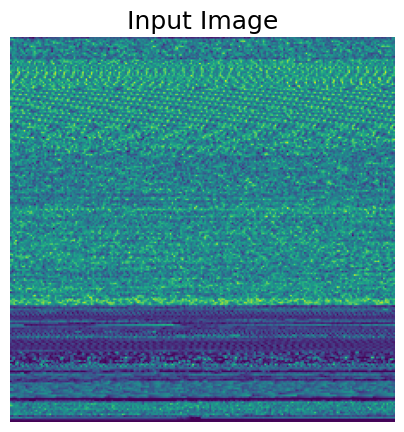

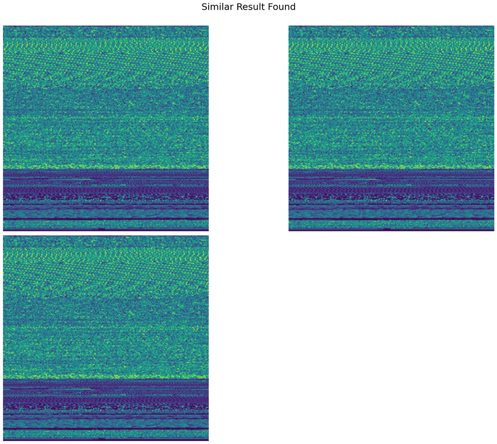

```python
similar_images = top_model.plot_similar_images(image_path = instance_image_path,number_of_images=num_similar_images)
```